# survmarker_simulation

## Overview

This vignette demonstrates the SurvMarker workflow using a gene expression dataset and a feature set generated through simulation, in which a predefined subset of features is artificially associated with patient survival. This example is intended solely to illustrate the usage of the package and does not represent a real biological scenario. A real biological application is presented in our manuscript.

Here, using simulated datasets, we illustrate: (i) selection of survival-associated Principal Components (PCs), (ii) PCA-based feature score generation. (iii) empirical-null calibrated feature scoring, and (iv) visualization utilities for diagnosing survival-associated features.

For real datasets (e.g., RNA-seq or miRNA expression), input matrices should be preprocessed prior to analysis. Raw count data should be normalized using Trimmed Mean of M-values (TMM) normalization and subsequently transformed to log2 scale (e.g., via edgeR, DESeq2) before applying SurvMarker.

```r
library(SurvMarker)
library(survival)
library(ggplot2)
```

## 1. Simulate expression and survival

## Data-generating mechanism (simulation)

We simulate a high-dimensional expression matrix with $n$ samples and $p$ features. A latent variable $z_i \sim N(0,1)$ induces a shared survival-associated signal across the first $n_{\text{signal}}$ features.

### Expression matrix

For sample $i=1,\dots,n$ and feature $j=1,\dots,p$,
$$X_{ij} =
\begin{cases}
\varepsilon_{ij} + \alpha z_i, & j = 1,\dots,n_{\text{signal}}, \\
\varepsilon_{ij}, & j = n_{\text{signal}}+1,\dots,p,
\end{cases}
\qquad
\varepsilon_{ij} \sim N(0,1),$$
where $\alpha>0$ controls the strength of the latent signal (here $\alpha = 1.5$).

### Survival model

Survival times follow a proportional hazards model with linear predictor
$$\eta_i = \gamma z_i,$$
where $\gamma$ controls the effect size of the latent factor on survival (here $\gamma = 0.9$). The hazard function is
$$\lambda_i(t) = \lambda_0 \exp(\eta_i),$$
with baseline hazard $\lambda_0 = 0.08$. Event times are generated as
$$T_i \sim \text{Exponential}\big(\lambda_0 \exp(\eta_i)\big).$$

### Right censoring

Independent censoring times are generated as
$$C_i \sim \text{Exponential}(0.02).$$
The observed time and event indicator are
$$\tilde{T}_i = \min(T_i, C_i), \qquad
\delta_i = \mathbb{I}(T_i \le C_i).$$

### Clinical covariates and risk groups

Two additional clinical covariates—age category (Young/Old) and sex (F/M)—are generated independently of the expression matrix. An ELN-like risk group is then assigned probabilistically based on the standardized latent survival factor $z_i$ and age, such that higher values of $z_i$ increase the probability of an Adverse risk classification and decrease the probability of a Favorable classification. The remaining probability mass is assigned to the Intermediate group, and all probabilities are renormalized to ensure valid group assignments across the Favorable, Intermediate, and Adverse categories.

```r
set.seed(111)

n <- 200
p <- 6000
n_signal <- 25   # features driven by survival factor

# Make batch factor dominate variance
z <- rnorm(n)

X <- matrix(rnorm(n * p), n, p)
X[, 1:n_signal] <- X[, 1:n_signal] + 1.5 * z

colnames(X) <- paste0("G", seq_len(p))
rownames(X) <- paste0("S", seq_len(n))

# Survival depends on z, not u
lp <- 0.9 * z
base_rate <- 0.08
T_event <- rexp(n, rate = base_rate * exp(scale(lp)))
C <- rexp(n, rate = 0.02)
time <- pmin(T_event, C)
status <- as.integer(T_event <= C)

# Simple covariates (optional)
AGE_CATEGORY <- sample(c("Young", "Old"), n, replace = TRUE)
SEX <- sample(c("F", "M"), n, replace = TRUE)

meta <- data.frame(
  AGE_CATEGORY = AGE_CATEGORY,
  SEX = SEX,
  stringsAsFactors = FALSE
)
rownames(meta) <- rownames(X)

# After z, AGE_CATEGORY, SEX, meta are created:

z_std <- as.numeric(scale(z))

# Adverse increases with survival factor z and age
p_adverse <- plogis(1.2*z_std + 0.8*(meta$AGE_CATEGORY == "Old") - 0.3)

# Favorable decreases with z and slightly with age
p_fav <- plogis(-1.0*z_std - 0.4*(meta$AGE_CATEGORY == "Old") + 0.2)

# Intermediate is what's left (with a floor to avoid negatives)
p_int <- 1 - p_adverse - p_fav
p_int[p_int < 0.05] <- 0.05

# Renormalize
s <- p_adverse + p_fav + p_int
p_adverse <- p_adverse/s; p_fav <- p_fav/s; p_int <- p_int/s

set.seed(111)
meta$ELN_2022_risk <- vapply(seq_len(nrow(meta)), function(i) {
  sample(c("Favorable","Intermediate","Adverse"), 1,
         prob = c(p_fav[i], p_int[i], p_adverse[i]))
}, character(1))

meta$ELN_2022_risk <- factor(meta$ELN_2022_risk,
                             levels = c("Favorable","Intermediate","Adverse"))
```

## 2. Generate PCA-based feature score

Feature importance is quantified by aggregating loadings across all survival-associated PCs using variance-based weighting, yielding a single score for each feature. Statistical significance is assessed via an empirical null distribution constructed from non–survival-associated PCs using 500 resampling iterations.

The resulting object includes a ranked feature table containing each feature’s aggregated score, empirical p-value, and FDR-adjusted p-value, along with PC-level summaries and diagnostic outputs. A key optional choice is whether to store the full null score matrix (`null_scores`) by setting (`store_null = TRUE`).

```r
# Ensure ELN is an ordered factor (recommended)
meta$ELN_2022_risk <- factor(
  meta$ELN_2022_risk,
  levels = c("Favorable", "Intermediate", "Adverse")
)

res <- pca_based_weighted_score(
  X = X,
  time = time,
  status = status,
  covar = meta[, c("ELN_2022_risk", "AGE_CATEGORY", "SEX"), drop = FALSE],
  n_pcs = 50,
  max_pcs = 50,
  pc_fdr_cutoff = 0.2,
  feature_fdr_cutoff = 0.05,
  null_B = 500,
  seed = 111,
  scale_pca = TRUE,
  store_null = TRUE,
  verbose = FALSE
)
```

## 3. Visualization

### PC1–PC2 scatter (example grouping)

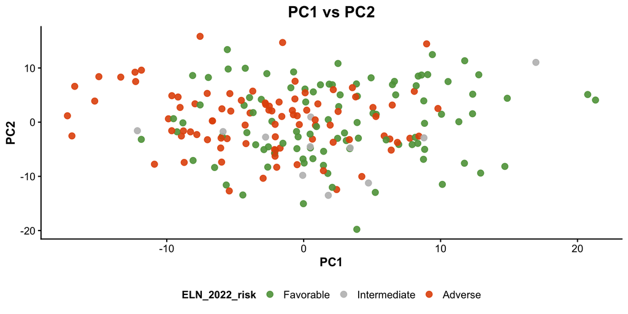

```r
# Define ELN-2022 color palette
eln_cols <- c(
  Favorable    = "#5E9F47",  # green
  Intermediate = "#bdbdbd",  # grey
  Adverse      = "#E35408"   # orange/red
)

# PC1–PC2 scatter colored by ELN-2022 risk
p_all_eln <- plot_pc12(
  res,
  meta,
  color_by = "ELN_2022_risk",
  color_values = eln_cols,
  theme_fn = ggplot2::theme_classic,
  base_size = 14,
  legend_position = "bottom",
  legend_text_size = 12
)

p_all_eln
```

### Top 2 survival-significant PCs

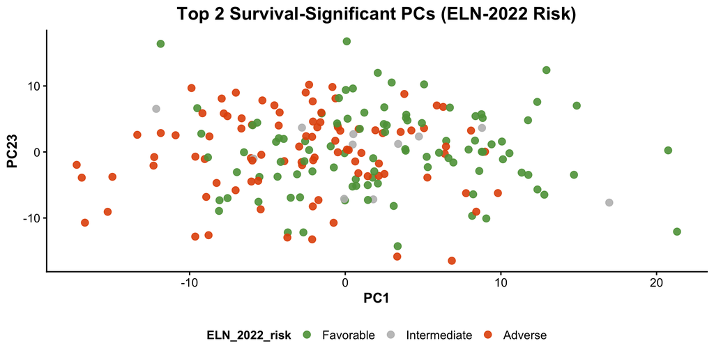

```r
p_sig_eln <- plot_top2_survival_pcs(
  res,
  meta = meta,
  color_by = "ELN_2022_risk",
  color_values = eln_cols,
  title = "Top 2 Survival-Significant PCs (ELN-2022 Risk)",
  theme_fn = ggplot2::theme_classic,
  base_size = 14,
  legend_position = "bottom",
  legend_text_size = 12
)

p_sig_eln
```

### Scree and cumulative variance

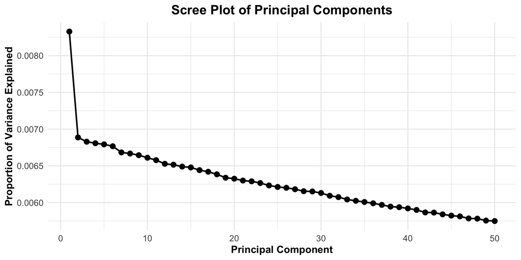

```r
plot_scree(res, n_pcs = 100)
```

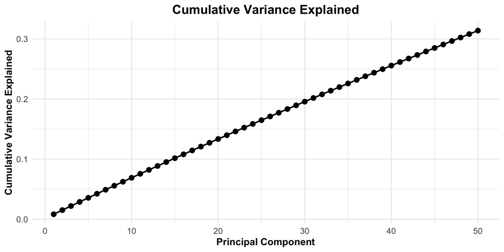

```r
plot_cumvar(res, n_pcs = 100)
```

### Empirical null vs observed score

We compare a simulated *true* feature to a null feature.

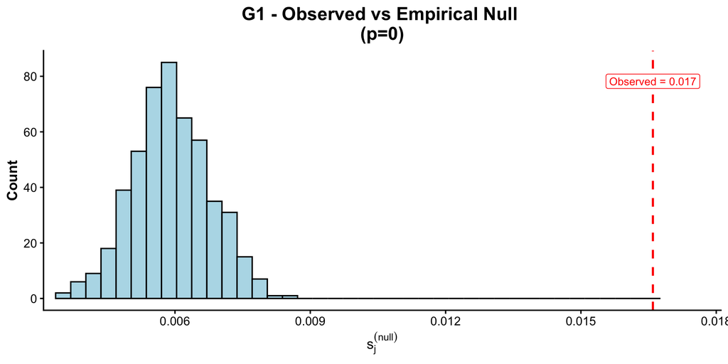

```r
true_feature <- res$feature_table$feature[1]
null_feature <- res$feature_table$feature[res$feature_table$p_emp >0.1][5]

plot_null_vs_observed(
  res, feature = true_feature, bins = 40,
  theme_fn = ggplot2::theme_classic,
  base_size = 14
)+
  scale_x_continuous(
    expand = expansion(mult = c(0.02, 0.1))
  )
```

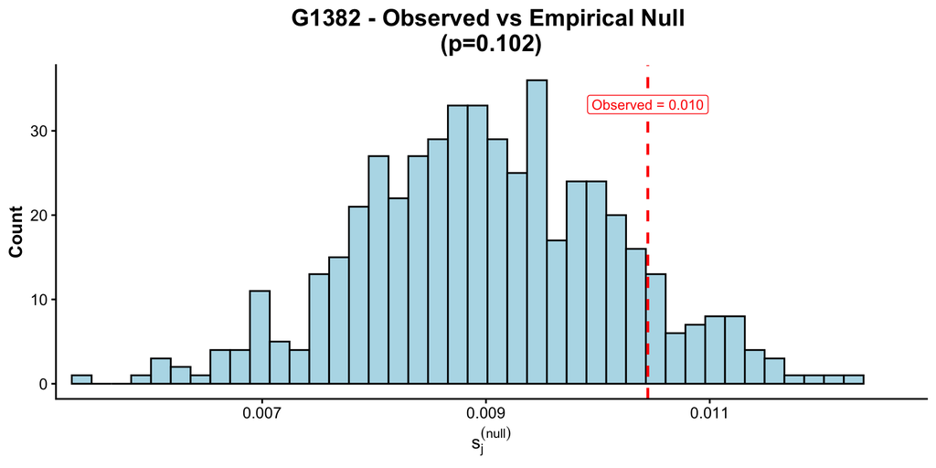

```r
plot_null_vs_observed(
  res, feature = null_feature, bins = 40,
  theme_fn = ggplot2::theme_classic,
  base_size = 14
)+
  scale_x_continuous(
    expand = expansion(mult = c(0.02, 0.08))
  )
```

## 4. Multi-PC sensitivity examination

We examine how the selected feature set changes as the number of PCs increases.

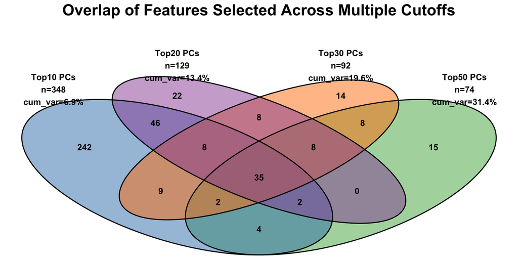

```r
pcobj <- run_survival_pca_multi_pc(
  X = X,
  time = time,
  status = status,
  covar = meta[, c("AGE_CATEGORY", "SEX"), drop = FALSE],
  pcs_to_run = c(10, 50, 20, 30),
  null_B = 300,
  store_null = TRUE,
  verbose = FALSE
)

venn_plot <- plot_venn(pcobj, pick = c(10, 50, 20, 30), cex = 1.0, cat_cex = 1.0,
          main = "Overlap of Features Selected Across Multiple Cutoffs")
```

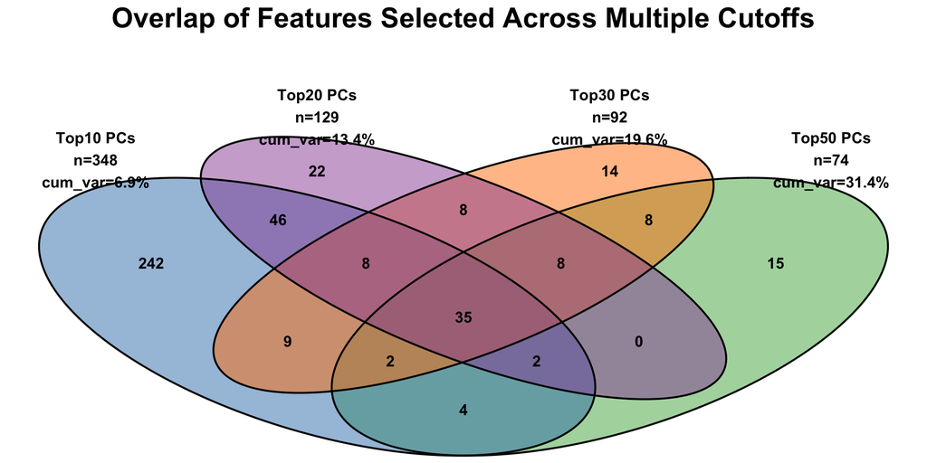

```r
venn_plot
```

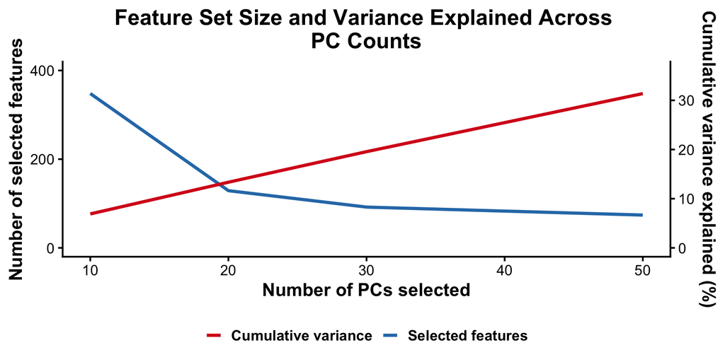

```r
tradeoff_plot <- plot_feature_set_tradeoff(pcobj)
tradeoff_plot
```

## Notes

- This simulation vignette runs quickly and is fully reproducible.
- For manuscripts, you can match plot aesthetics by passing `base_size`, `theme_fn`, and consistent color mappings as shown above.